# 2026-02-26-covariance

## Covariance

Covariance is a statistical measure of the joint variability of two random variables. It indicates whether two variables move in the same or opposite directions.

It can be

- positive: indicating that two variables change together
- negative: indicating they change in opposite directions
- or zero: indicating absolute independence from each other

**Formula**: $cov(X,Y)=\frac{\sum_{i=1}^{n}{(X_i-\bar{X})(Y_i-\bar{Y})}}{n-1}$

For populations n-1 in the denominator changes to the whole population size N.

### Calculate Covariance in Python

```python
from statistics import covariance
covariance([1,2,3], [1,2,3])
```

```
1.0
```

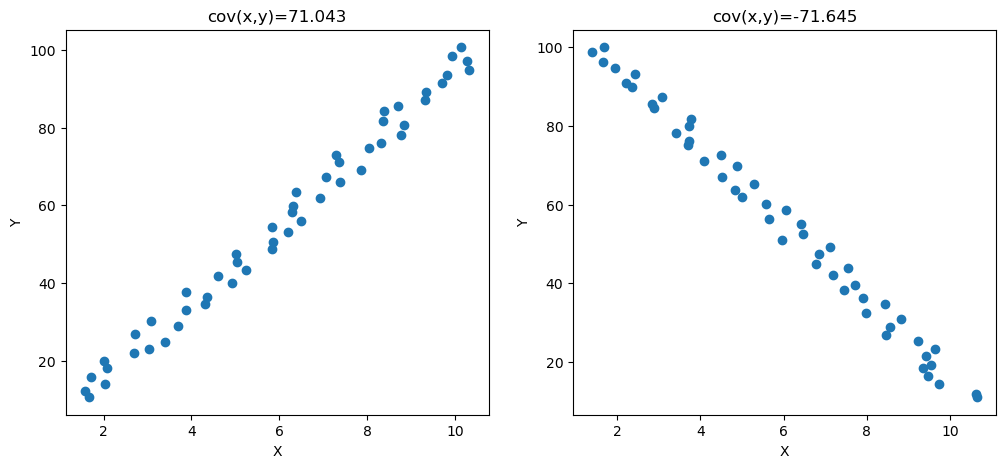

```python
import numpy as np
import matplotlib.pyplot as plt
from statistics import covariance

def plot(x,y):
    cov_xy = covariance(x,y)
    plt.scatter(x,y)
    plt.title(f"cov(x,y)={cov_xy:.3f}")
    plt.xlabel("X")
    plt.ylabel("Y")

# positive correlation
x = np.linspace(1,10,50) + np.random.rand(50)
y = np.linspace(10,100,50) + np.random.rand(50)

plt.figure(figsize=(12,5))
plt.subplot(1,2,1)
plot(x,y)

# negative correlation
x = np.linspace(1,10,50) + np.random.rand(50)
y = np.linspace(10,100,50) + np.random.rand(50)
y = y[::-1]

plt.subplot(1,2,2)
plot(x,y)

plt.show()
```

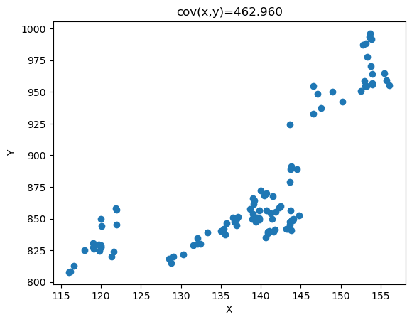

|  | Date | Apple | Alphabet | Bank of America (BAC) |
| --- | --- | --- | --- | --- |
| 0 | 2017-01-03 | 116.15 | 808.01 | 22.53 |
| 1 | 2017-01-04 | 116.02 | 807.77 | 22.95 |
| 2 | 2017-01-05 | 116.61 | 813.02 | 22.68 |
| 3 | 2017-01-06 | 117.91 | 825.21 | 22.68 |
| 4 | 2017-01-09 | 118.99 | 827.18 | 22.55 |
| 5 | 2017-01-10 | 119.11 | 826.01 | 22.94 |
| 6 | 2017-01-11 | 119.75 | 829.86 | 23.07 |
| 7 | 2017-01-12 | 119.25 | 829.53 | 22.92 |
| 8 | 2017-01-13 | 119.04 | 830.94 | 23.01 |
| 9 | 2017-01-17 | 120.00 | 827.46 | 22.05 |

```python
import pandas as pd

df = pd.read_excel("stock_prices.xlsx")

plot(df.Apple, df.Alphabet)
plt.show()
df.head(10)
```

**Interpretation**: There seems to be a positive correlation between the prices of Apple and Alphabet stocks.

### Covariance vs Correlation

Both assess the direction of the relationship between two variables. The difference is that correlation also assesses its strength and is a standardized measure, comparable across data sets.

### Interpreting Covariance

Covariance can be tough to interpret as its formula allows values to range from negative to positive infinity and it is strongly effected by the magnitude and scale of the variables. A high or low covariance doesn't imply strong or weak correlation. Covariance doesn't give reliable information about the strength of the relationship between variables, just about the direction. To assess its strength use the correlation coefficient instead, which standardizes covariance to a value between -1 and 1.

## Covariance matrix

The covariance matrix, also known as variance-covariance matrix, is a square matrix that represents the variance of each element along the major diagonal, and the covariance among the non-diagonal elements.

$\begin{bmatrix}var(X) & cov(X, Y) \\ cov(Y, X) & var(Y)\end{bmatrix}$

```python
import numpy as np
import pandas as pd

cov_matrix = np.cov(df.Apple, df.Alphabet)
pd.DataFrame(data=cov_matrix, index=["X","Y"], columns=["X","Y"])
```

|  | X | Y |
| --- | --- | --- |
| X | 125.600244 | 462.959518 |
| Y | 462.959518 | 2752.404975 |